# Regression Models Course Project (Coursera - JOHNS HOPKINS)

Juan Carlos Rodriguez Rojo

20 de marzo de 2016

# Motor Trend. Relationship between MPG (miles per gallon) and the kind of transmission

## Executive Summary

### Introduction

In Motor Trend we have wondered about the power consumption of the motor vehicle. Specifically, we wonder if there is difference in consumption, measured in miles per gallon (MPG), between the cars that have manual transmission and with automatic transmission.

What kind of transmission is better in terms of energy consumption? What is the difference between the two types of transmission?

### Method

To answer these questions, we will use the mtcars file, which contains information about all the variables involved. The mtcars file comprises fuel consumption (miles per gallon) and some aspects of vehicle for 32 models.

First, we examine the distribution of MPG Variable comparing the two types of transmission. Thus, we can get a first impression about the change in consumption due to the change of transmission.

But to address the issue accurately, we must go further. If we want to know if different consumption according to the type of transmission, consumption being a continuous variable, we could try to predict consumption using as independent variable transmission. Now, since we have other variables that can influence consumption, we will first observe what variables influence more on consumption and what is the position of the transmission in the set of variables. Depending on the results, we construct a final model.

### Conclusion

Summarily, the difference in MPG between two transmissions is significantly favorable to the manual transmission. However, there are other variables with significant influence, as shown in a process of stepwise regression, which are three independent variables: wt, am and qsec.

Wt coefficients and am are significant and opposite. If we look at the effect of the interaction between wt and am about MPG, we see that this interaction must be considered in the model.

The result is that am has a major impact, with lower consumption of the manual transmission, but the growth of weight can neutralize the advantage.

## Appendix

### Exploratory analysis

Load and summarize data

```r
library(ggplot2)
data(mtcars)
summary(mtcars)
```

```
##       mpg             cyl             disp             hp
##  Min.   :10.40   Min.   :4.000   Min.   : 71.1   Min.   : 52.0
##  1st Qu.:15.43   1st Qu.:4.000   1st Qu.:120.8   1st Qu.: 96.5
##  Median :19.20   Median :6.000   Median :196.3   Median :123.0
##  Mean   :20.09   Mean   :6.188   Mean   :230.7   Mean   :146.7
##  3rd Qu.:22.80   3rd Qu.:8.000   3rd Qu.:326.0   3rd Qu.:180.0
##  Max.   :33.90   Max.   :8.000   Max.   :472.0   Max.   :335.0
##       drat             wt             qsec             vs
##  Min.   :2.760   Min.   :1.513   Min.   :14.50   Min.   :0.0000
##  1st Qu.:3.080   1st Qu.:2.581   1st Qu.:16.89   1st Qu.:0.0000
##  Median :3.695   Median :3.325   Median :17.71   Median :0.0000
##  Mean   :3.597   Mean   :3.217   Mean   :17.85   Mean   :0.4375
##  3rd Qu.:3.920   3rd Qu.:3.610   3rd Qu.:18.90   3rd Qu.:1.0000
##  Max.   :4.930   Max.   :5.424   Max.   :22.90   Max.   :1.0000
##        am              gear            carb
##  Min.   :0.0000   Min.   :3.000   Min.   :1.000
##  1st Qu.:0.0000   1st Qu.:3.000   1st Qu.:2.000
##  Median :0.0000   Median :4.000   Median :2.000
##  Mean   :0.4062   Mean   :3.688   Mean   :2.812
##  3rd Qu.:1.0000   3rd Qu.:4.000   3rd Qu.:4.000
##  Max.   :1.0000   Max.   :5.000   Max.   :8.000
```

```r
mtcars$am <- factor(mtcars$am, labels = c("automatic", "manual"))
```

Difference between manual and automatic transmission. Box plot and analytics.

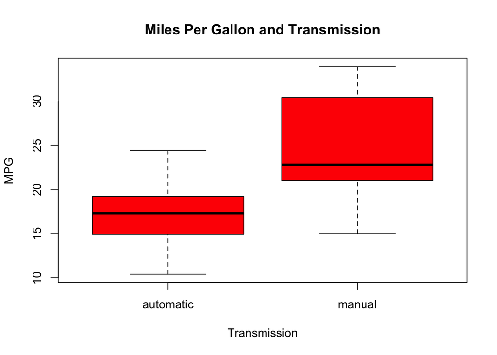

```r
#boxplot
boxplot(mpg ~ am, data = mtcars, col = "red", xlab="Transmission", ylab="MPG", main="Miles Per Gallon and Transmission")
```

```r
#analytics
difference <- t.test(mpg ~ am, data = mtcars)
difference$p.value
```

```
## [1] 0.001373638
```

```r
difference$estimate
```

```
## mean in group automatic    mean in group manual
##                17.14737                24.39231
```

### Model

Initial model and better model without interaction.

```r
#initial model
fullLm <- lm(mpg ~ ., data=mtcars)
#better model
stepLm <- step(fullLm, direction = "backward")
```

```
## Start:  AIC=70.9
## mpg ~ cyl + disp + hp + drat + wt + qsec + vs + am + gear + carb
##
##        Df Sum of Sq    RSS    AIC
## - cyl   1    0.0799 147.57 68.915
## - vs    1    0.1601 147.66 68.932
## - carb  1    0.4067 147.90 68.986
## - gear  1    1.3531 148.85 69.190
## - drat  1    1.6270 149.12 69.249
## - disp  1    3.9167 151.41 69.736
## - hp    1    6.8399 154.33 70.348
## - qsec  1    8.8641 156.36 70.765
## <none>              147.49 70.898
## - am    1   10.5467 158.04 71.108
## - wt    1   27.0144 174.51 74.280
##
## Step:  AIC=68.92
## mpg ~ disp + hp + drat + wt + qsec + vs + am + gear + carb
##
##        Df Sum of Sq    RSS    AIC
## - vs    1    0.2685 147.84 66.973
## - carb  1    0.5201 148.09 67.028
## - gear  1    1.8211 149.40 67.308
## - drat  1    1.9826 149.56 67.342
## - disp  1    3.9009 151.47 67.750
## - hp    1    7.3632 154.94 68.473
## <none>              147.57 68.915
## - qsec  1   10.0933 157.67 69.032
## - am    1   11.8359 159.41 69.384
## - wt    1   27.0280 174.60 72.297
##
## Step:  AIC=66.97
## mpg ~ disp + hp + drat + wt + qsec + am + gear + carb
##
##        Df Sum of Sq    RSS    AIC
## - carb  1    0.6855 148.53 65.121
## - gear  1    2.1437 149.99 65.434
## - drat  1    2.2139 150.06 65.449
## - disp  1    3.6467 151.49 65.753
## - hp    1    7.1060 154.95 66.475
```

[output cut: 44 more lines]

```
##        Df Sum of Sq    RSS    AIC
## - hp    1     9.219 169.29 61.307
## <none>              160.07 61.515
## - qsec  1    20.225 180.29 63.323
## - am    1    25.993 186.06 64.331
## - wt    1    78.494 238.56 72.284
##
## Step:  AIC=61.31
## mpg ~ wt + qsec + am
##
##        Df Sum of Sq    RSS    AIC
## <none>              169.29 61.307
## - am    1    26.178 195.46 63.908
## - qsec  1   109.034 278.32 75.217
## - wt    1   183.347 352.63 82.790
```

```r
summary(stepLm)
```

```
##
## Call:
## lm(formula = mpg ~ wt + qsec + am, data = mtcars)
##
## Residuals:
##     Min      1Q  Median      3Q     Max
## -3.4811 -1.5555 -0.7257  1.4110  4.6610
##
## Coefficients:
##             Estimate Std. Error t value Pr(>|t|)
## (Intercept)   9.6178     6.9596   1.382 0.177915
## wt           -3.9165     0.7112  -5.507 6.95e-06 ***
## qsec          1.2259     0.2887   4.247 0.000216 ***
## ammanual      2.9358     1.4109   2.081 0.046716 *
## ---
## Signif. codes:  0 '***' 0.001 '**' 0.01 '*' 0.05 '.' 0.1 ' ' 1
##
## Residual standard error: 2.459 on 28 degrees of freedom
## Multiple R-squared:  0.8497, Adjusted R-squared:  0.8336
## F-statistic: 52.75 on 3 and 28 DF,  p-value: 1.21e-11
```

Exploratory Interaction between am and weight

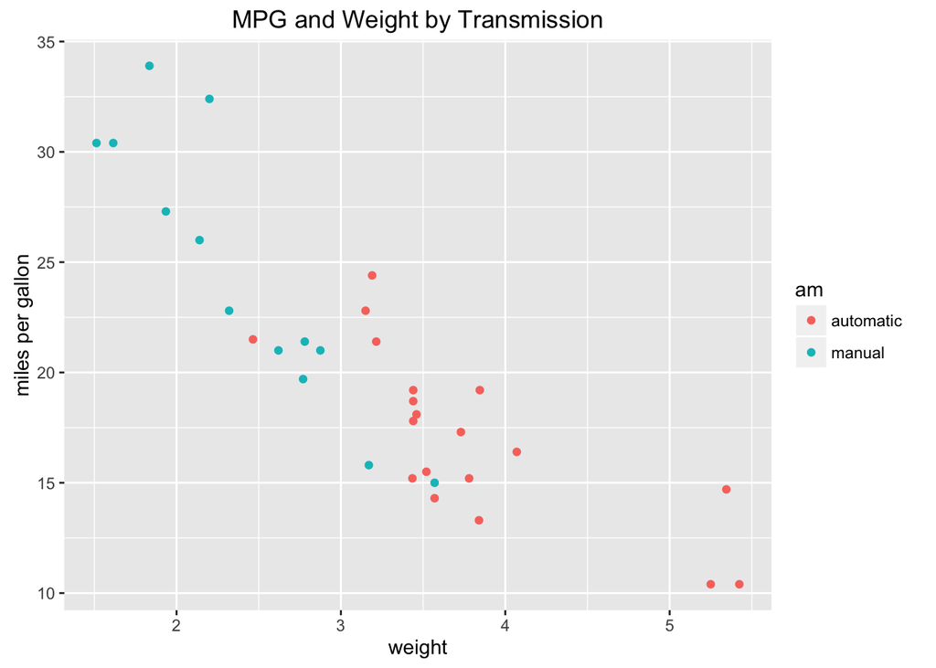

```r
#Visual Interaction
ggplot(mtcars, aes(x=wt, y=mpg, group=am, color=am)) + geom_point() + #scale_colour_discrete(labels=c("Automatic", "Manual")) +
xlab("weight") + ylab("miles per gallon") + ggtitle("MPG and Weight by Transmission")
```

Final model with interaction

```r
#Final model
finalLm<-lm(mpg ~ wt + qsec + am + wt:am, data=mtcars)
summary(finalLm)
```

```
##
## Call:
## lm(formula = mpg ~ wt + qsec + am + wt:am, data = mtcars)
##
## Residuals:
##     Min      1Q  Median      3Q     Max
## -3.5076 -1.3801 -0.5588  1.0630  4.3684
##
## Coefficients:
##             Estimate Std. Error t value Pr(>|t|)
## (Intercept)    9.723      5.899   1.648 0.110893
## wt            -2.937      0.666  -4.409 0.000149 ***
## qsec           1.017      0.252   4.035 0.000403 ***
## ammanual      14.079      3.435   4.099 0.000341 ***
## wt:ammanual   -4.141      1.197  -3.460 0.001809 **
## ---
## Signif. codes:  0 '***' 0.001 '**' 0.01 '*' 0.05 '.' 0.1 ' ' 1
##
## Residual standard error: 2.084 on 27 degrees of freedom
## Multiple R-squared:  0.8959, Adjusted R-squared:  0.8804
## F-statistic: 58.06 on 4 and 27 DF,  p-value: 7.168e-13
```

```r
#Evaluation model
anova(fullLm, stepLm, finalLm)
```

```
## Analysis of Variance Table
##
## Model 1: mpg ~ cyl + disp + hp + drat + wt + qsec + vs + am + gear + carb
## Model 2: mpg ~ wt + qsec + am
## Model 3: mpg ~ wt + qsec + am + wt:am
##   Res.Df    RSS Df Sum of Sq      F  Pr(>F)
## 1     21 147.49
## 2     28 169.29 -7   -21.791 0.4432 0.86361
## 3     27 117.28  1    52.010 7.4050 0.01279 *
## ---
## Signif. codes:  0 '***' 0.001 '**' 0.01 '*' 0.05 '.' 0.1 ' ' 1
```

```r
summary(finalLm)$coef
```

```
##              Estimate Std. Error   t value     Pr(>|t|)
## (Intercept)  9.723053  5.8990407  1.648243 0.1108925394
## wt          -2.936531  0.6660253 -4.409038 0.0001488947
## qsec         1.016974  0.2520152  4.035366 0.0004030165
## ammanual    14.079428  3.4352512  4.098515 0.0003408693
## wt:ammanual -4.141376  1.1968119 -3.460340 0.0018085763
```

Residual plots

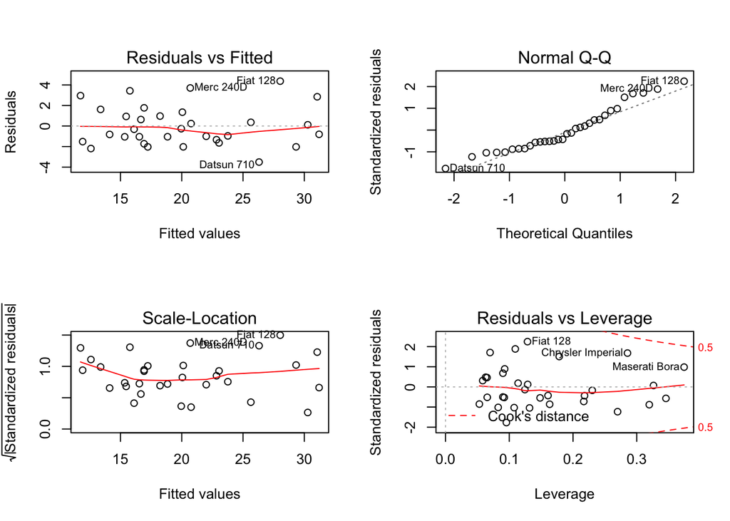

```r
#Residual plots
par(mfrow = c(2, 2))
plot(finalLm)
```